# Project Code

Team SAID

Author

Davis Johnson, Andy Wen, Isabel Podolsky, Shray Vaidya

Published

May 23, 2023

Abstract

*This file contains the code for the project on NBA All-Star Prediction, as part of the STAT303-3 course in Spring 2023*.

```python
import pandas as pd
import numpy as np
import seaborn as sns
import matplotlib.pyplot as plt
from sklearn.metrics import mean_squared_error
from sklearn.model_selection import cross_val_score,train_test_split, KFold, cross_val_predict
from sklearn.metrics import mean_squared_error,r2_score,roc_curve,auc,precision_recall_curve, accuracy_score, \
recall_score, precision_score, confusion_matrix, make_scorer, roc_auc_score
from sklearn.tree import DecisionTreeRegressor,DecisionTreeClassifier
from sklearn.model_selection import GridSearchCV, ParameterGrid, StratifiedKFold, RandomizedSearchCV, cross_validate
from sklearn.ensemble import VotingRegressor, VotingClassifier, StackingRegressor, StackingClassifier, GradientBoostingRegressor,GradientBoostingClassifier, BaggingRegressor,BaggingClassifier,RandomForestRegressor,RandomForestClassifier,AdaBoostRegressor,AdaBoostClassifier
from sklearn.linear_model import LinearRegression,LogisticRegression, LassoCV, RidgeCV, ElasticNetCV
from sklearn.neighbors import KNeighborsRegressor
import itertools as it
import time as time
import io
import xgboost as xgb
import warnings
warnings.filterwarnings('ignore')
```

## 1 Data quality check / cleaning / preparation

```python
#code used by some group members to render datasets:
#from google.colab import files
#uploaded = files.upload()
```

```python
# reading in the data - train and test
nba_2017 = pd.read_csv('NBA Players Stats 201718.csv')
nba_2018 = pd.read_csv('NBA Players Stats 201819.csv')
```

### 1.1 Data cleaning

*By Davis Johnson*

```python
#Train Dataset#

## getting rid of '//' characters in player names
nba_2017['Player'] = nba_2017['Player'].str.split('\\').str[0]

## If players played for more than one team, we want to only keep the row that has their total stats for the year
## applying boolean mask to get of rid of extra rows belonging to players and only keeping their 'TOT' rows
duplicated_players = nba_2017['Player'].duplicated(keep=False)
mask = duplicated_players & (nba_2017['Tm'] == 'TOT')
filtered_df = nba_2017[mask]

## creating seperate subset of players that don't have more than one row
single_team_df = nba_2017[~duplicated_players]

## combining previously created subset with players that played for more than one team and now only have one row assigned to them
nba_2017_2018 = pd.concat([filtered_df, single_team_df])
nba_2017_2018 = nba_2017_2018.reset_index(drop=True)

## filling all N/A values with 0, since we are assuming players have no stats for these data points
nba_2017_2018.fillna(0, inplace=True)
```

```python
## repeating the process for test dataset
nba_2018['Player'] = nba_2018['Player'].str.split('\\').str[0]
duplicated_players = nba_2018['Player'].duplicated(keep=False)
mask = duplicated_players & (nba_2018['Tm'] == 'TOT')
filtered_df = nba_2018[mask]
single_team_df = nba_2018[~duplicated_players]
nba_2018_2019 = pd.concat([filtered_df, single_team_df])
nba_2018_2019 = nba_2018_2019.reset_index(drop=True)
nba_2018_2019.fillna(0, inplace=True)
```

### 1.2 Data preparation

*By Davis Johnson*

The following data preparation steps helped us to prepare our data for implementing various modeling / validation techniques:

1. We want to predict All-Star appearances. Thus, we manually created a response column using binary classification. A `1` in the column signifies that the player was an All-Star in the following year.
2. We also performed some basic data preparation techniques (dropping non-relevant predictors, removing players from the analysis who appeared in a limited number of games)

```python
## Train dataset

## dropping predictors that won't factor into our analysis, we our focusing on stats
nba_2017_2018 = nba_2017_2018.drop(columns=['Rk','Tm', 'Pos'], axis=1)

## removing players who played less than 20 games
nba_2017_2018 = nba_2017_2018[nba_2017_2018['G'] >= 20]
nba_2017_2018 = nba_2017_2018.reset_index(drop=True)

## converting stats into percentage form
percentage_columns = ['FG%', '3P%', '2P%', 'eFG%', 'FT%']
for col in percentage_columns:
    nba_2017_2018[col] = nba_2017_2018[col] * 100

## creating response variable
## manually creating list of the following year's NBA All-Stars
all_star_list = ['Kemba Walker', 'Kyrie Irving', 'Kawhi Leonard', 'Giannis Antetokounmpo',
                'Joel Embiid', 'Kyle Lowry', 'Victor Oladipo', 'Khris Middleton', 'Bradley Beal',
                'Ben Simmons', 'Blake Griffin', 'Nikola Vučević', "D'Angelo Russell",
                'Stephen Curry', 'James Harden', 'Kevin Durant', 'Paul George', 'LeBron James',
                'Russell Westbrook', 'Damian Lillard', 'Klay Thompson', 'Anthony Davis',
                'LaMarcus Aldridge', 'DeMarcus Cousins', 'Nikola Jokić', 'Karl-Anthony Towns']

## assigning a 1 to rows in a new column if the player name is in the list above
nba_2017_2018['AS_NY'] = nba_2017_2018['Player'].apply(lambda x: 1 if x in all_star_list else 0)
```

```python
## repeating process for test dataset

nba_2018_2019 = nba_2018_2019.drop(columns=['Rk','Tm', 'Pos'], axis=1)
nba_2018_2019 = nba_2018_2019[nba_2018_2019['G'] >= 20]
nba_2018_2019 = nba_2018_2019.reset_index(drop=True)

percentage_columns = ['FG%', '3P%', '2P%', 'eFG%', 'FT%']
for col in percentage_columns:
    nba_2018_2019[col] = nba_2018_2019[col] * 100

all_star_list = ['Kemba Walker', 'Trae Young', 'Giannis Antetokounmpo', 'Pascal Siakam', 'Joel Embiid',
                'Kyle Lowry', 'Ben Simmons', 'Jimmy Butler', 'Khris Middleton', 'Bam Adebayo',
                'Jayson Tatum', 'Domantas Sabonis', 'James Harden', 'Luka Dončić', 'LeBron James',
                'Kawhi Leonard', 'Anthony Davis', 'Chris Paul', 'Russell Westbrook', 'Damian Lillard',
                'Donovan Mitchell', 'Brandon Ingram', 'Nikola Jokić', 'Rudy Gobert', 'Devin Booker']
nba_2018_2019['AS_NY'] = nba_2018_2019['Player'].apply(lambda x: 1 if x in all_star_list else 0)
```

```python
X_train = nba_2017_2018.drop(['Player', 'AS_NY'], axis=1)
y_train = nba_2017_2018['AS_NY']

X_test = nba_2018_2019.drop(['Player', 'AS_NY'], axis=1)
y_test = nba_2018_2019['AS_NY']
```

### 1.3 Distribution of response

*By Davis Johnson*

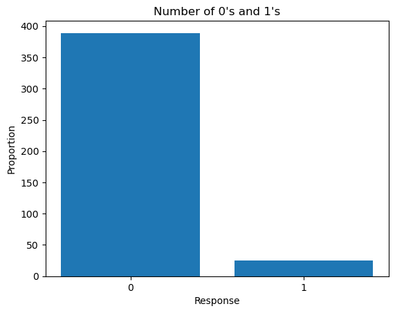

```python
## bar plot for distribution of response for train data
proportions = nba_2017_2018['AS_NY'].value_counts()
plt.bar(proportions.index.astype(str), proportions.values)
plt.xlabel('Response')
plt.ylabel('Proportion')
plt.title('Number of 0\'s and 1\'s')
```

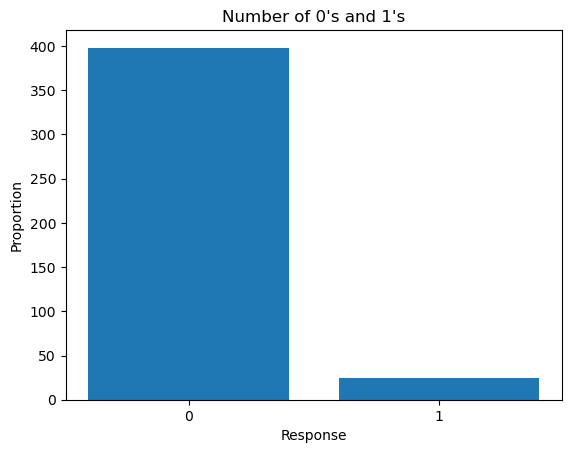

```python
## bar plot for distribution of response for test data
proportions = nba_2018_2019['AS_NY'].value_counts()
plt.bar(proportions.index.astype(str), proportions.values)
plt.xlabel('Response')
plt.ylabel('Proportion')
plt.title('Number of 0\'s and 1\'s')
```

For both datasets, we see very skewed class distributions. This makes sense, as there are over 400 NBA players in a given year and only about 25 are voted as an All-Star each year. We do keep this in mind during model development by using StratifiedKFold.

## 2 Exploratory data analysis

### 2.1 Correlation Table (Andy)

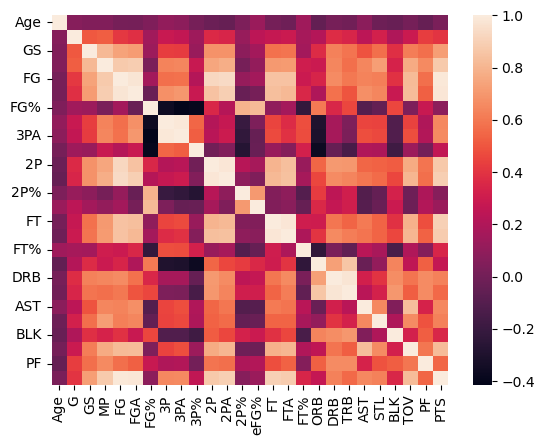

```python
# developing heatmap to analyze correlations
x_train_eda = nba_2017_2018.iloc[:, 1:-1]
sns.heatmap(x_train_eda.corr())
```

### 2.2 Variance Inflation Factor (Andy)

```python
# Analyzing Variance Inflation Factor
from statsmodels.stats.outliers_influence import variance_inflation_factor
from statsmodels.tools.tools import add_constant

# analyze VIF for training data (2017-2018)
x_train_vif = nba_2017_2018.iloc[:, 1:-1]
X = add_constant(x_train_vif)
vif_data = pd.DataFrame()
vif_data["feature"] = X.columns

for i in range(len(X.columns)):
    vif_data.loc[i,'VIF'] = variance_inflation_factor(X.values, i)

# delete columns with high VIF values
test_vif = vif_data.sort_values(by = 'VIF', ascending = False)
test_vif
```

|  | feature | VIF |
| --- | --- | --- |
| 6 | FGA | 9278.338644 |
| 26 | PTS | 6855.495654 |
| 12 | 2PA | 5214.888899 |
| 5 | FG | 4760.500282 |
| 20 | TRB | 2455.633794 |
| 9 | 3PA | 2136.962689 |
| 11 | 2P | 1669.580429 |
| 19 | DRB | 1382.304451 |
| 8 | 3P | 568.795838 |
| 15 | FT | 386.671118 |
| 0 | const | 359.615994 |
| 18 | ORB | 250.011013 |
| 16 | FTA | 85.359677 |
| 7 | FG% | 23.315430 |
| 14 | eFG% | 14.742887 |
| 4 | MP | 12.792623 |
| 24 | TOV | 10.272942 |
| 21 | AST | 5.418226 |
| 13 | 2P% | 4.116444 |
| 3 | GS | 3.556087 |
| 25 | PF | 3.075280 |
| 22 | STL | 2.571860 |
| 23 | BLK | 2.378908 |
| 17 | FT% | 2.192007 |
| 10 | 3P% | 2.185635 |
| 2 | G | 1.627709 |
| 1 | Age | 1.119090 |

## 3 Developing the model: Hyperparameter tuning

### 3.1 AdaBoost and Gradient Boost

*By Andy Wen*

```python
# grid search for optimal hyperparameters to minimize recall and accuracy

model = GradientBoostingClassifier(random_state=1)
param_grid = {
    'n_estimators': [50, 100, 150, 200, 250, 300, 350, 400],
    'max_depth': [5,10,15,20,25,30,35,40],
    'learning_rate': [0.001, 0.01, 0.1, 0.5, 1, 2],
    'subsample': [0.1, 0.25, 0.4, 0.5, 0.6, 0.75, 1.0]
}

# define the evaluation procedure
cv = StratifiedKFold(n_splits=5, shuffle=True, random_state=1)
# define the grid search procedure
grid_search = GridSearchCV(estimator=model,
                           param_grid = param_grid,
                           n_jobs=-1,
                           cv=cv,
                           verbose = True,
                           scoring= 'roc_auc')

# execute the grid search
grid_result = grid_search.fit(X_train, y_train)

# summarize the best score and configuration
print("Best: %f using %s" % (grid_result.best_score_, grid_result.best_params_))
```

```
Fitting 5 folds for each of 2688 candidates, totalling 13440 fits
Best: 0.989144 using {'learning_rate': 0.001, 'max_depth': 15, 'n_estimators': 100, 'subsample': 0.6}
```

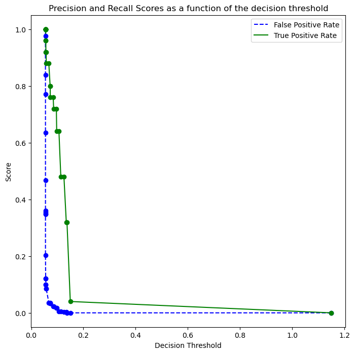

```python
# Model based on the optimal parameters
gradient_boost_model = GradientBoostingClassifier(random_state=1,
                                   max_depth=15,
                                   learning_rate=0.001,
                                   subsample=0.6,
                                   n_estimators=100).fit(X_train,y_train)


cross_val_ypred = cross_val_predict(GradientBoostingClassifier(random_state=1,
                                                               max_depth=15,
                                                               learning_rate=0.001,
                                                               subsample=0.6,
                                                               n_estimators=100),
                                    X_train,
                                    y_train,
                                    cv = 5,
                                    method = 'predict_proba')


fpr, tpr, thresholds = roc_curve(y_train, cross_val_ypred[:,1])

def plot_fpr_tpr_vs_threshold(fpr, tpr, thresholds):
    plt.figure(figsize=(8, 8))
    plt.title("Precision and Recall Scores as a function of the decision threshold")
    plt.plot(thresholds, fpr, "b--", label= "False Positive Rate")
    plt.plot(thresholds, tpr, "g-", label= "True Positive Rate")
    plt.plot(thresholds, fpr, "o", color = 'blue')
    plt.plot(thresholds, tpr, "o", color = 'green')
    plt.ylabel("Score")
    plt.xlabel("Decision Threshold")
    plt.legend(loc='best')
    plt.legend()

plot_fpr_tpr_vs_threshold(fpr, tpr, thresholds)
```

```python
# look at feature importances
feature_importance_grad_boost = pd.DataFrame({'variables' : X_train.columns,
                                            'feature_importance' : gradient_boost_model.feature_importances_})

feature_importance_grad_boost.sort_values('feature_importance', ascending = False)
```

|  | variables | feature_importance |
| --- | --- | --- |
| 25 | PTS | 0.393900 |
| 4 | FG | 0.192610 |
| 13 | eFG% | 0.104400 |
| 23 | TOV | 0.063095 |
| 18 | DRB | 0.033833 |
| 7 | 3P | 0.022006 |
| 20 | AST | 0.021990 |
| 14 | FT | 0.019588 |
| 12 | 2P% | 0.018270 |
| 19 | TRB | 0.017635 |
| 3 | MP | 0.014176 |
| 16 | FT% | 0.012957 |
| 8 | 3PA | 0.012922 |
| 2 | GS | 0.009819 |
| 17 | ORB | 0.007783 |
| 5 | FGA | 0.007196 |
| 24 | PF | 0.007095 |
| 21 | STL | 0.006885 |
| 15 | FTA | 0.005351 |
| 0 | Age | 0.005221 |
| 9 | 3P% | 0.004533 |
| 10 | 2P | 0.004368 |
| 1 | G | 0.003747 |
| 22 | BLK | 0.003698 |
| 11 | 2PA | 0.003580 |
| 6 | FG% | 0.003343 |

```python
# Thresholds with TPR and FPR
all_thresholds = np.concatenate([thresholds.reshape(-1,1), tpr.reshape(-1,1), fpr.reshape(-1,1)], axis = 1)

FPR_below_10 = all_thresholds[all_thresholds[:,2] < 0.10, :]

# we want to maximize TPR while minimizing FPR so go for last one
optimal_thres = FPR_below_10[FPR_below_10.shape[0]-1][0]
```

```
Accuracy:  89.12529550827422
ROC-AUC:  0.9009045226130654
Precision:  0.3157894736842105
Recall:  0.72
```

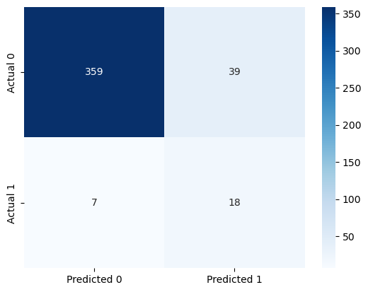

```python
# Performance metrics computation for the optimum decision threshold probability
desired_threshold = optimal_thres

y_pred_prob = gradient_boost_model.predict_proba(X_test)[:,1]

# Classifying observations in the positive class (y = 1) if the predicted probability is greater
# than the desired decision threshold probability
y_pred = y_pred_prob > desired_threshold
y_pred = y_pred.astype(int)

#Computing the accuracy
print("Accuracy: ",accuracy_score(y_pred, y_test)*100)

#Computing the ROC-AUC
fpr, tpr, auc_thresholds = roc_curve(y_test, y_pred_prob)
print("ROC-AUC: ",auc(fpr, tpr))# AUC of ROC

#Computing the precision and recall
print("Precision: ", precision_score(y_test, y_pred))
print("Recall: ", recall_score(y_test, y_pred))

#Confusion matrix
cm = pd.DataFrame(confusion_matrix(y_test, y_pred),
                  columns=['Predicted 0', 'Predicted 1'], index = ['Actual 0', 'Actual 1'])
sns.heatmap(cm, annot=True, cmap='Blues', fmt='g');
```

```python
y_pred = gradient_boost_model.predict(X_train)

accuracy = accuracy_score(y_train, y_pred)
recall = recall_score(y_train, y_pred)
precision = precision_score(y_train, y_pred)
confusion_mat = confusion_matrix(y_train, y_pred)

print("Accuracy:", accuracy)
print("Recall:", recall)
print("Precision:", precision)
print("Confusion Matrix:")
print(confusion_mat)
```

```
Accuracy: 0.9396135265700483
Recall: 0.0
Precision: 0.0
Confusion Matrix:
[[389   0]
 [ 25   0]]
```

```python
# Creating optimal classifier tree
model = AdaBoostClassifier(random_state=1)

grid = dict()
grid['n_estimators'] = [450, 500, 550]
grid['learning_rate'] = [0.01, 0.02, 0.03]
grid['base_estimator'] = [DecisionTreeClassifier(max_depth=1),DecisionTreeClassifier(max_depth=2),
                       DecisionTreeClassifier(max_depth=3)]

# define the evaluation procedure
cv = StratifiedKFold(n_splits=5, shuffle=True, random_state=1)
# define the grid search procedure
grid_search = GridSearchCV(estimator=model,
                           param_grid=grid,
                           n_jobs=-1,
                           cv=cv,
                           scoring= 'roc_auc',
                           verbose = True)

# execute the grid search
grid_result = grid_search.fit(X_train, y_train)
# summarize the best score and configuration
print("Best: %f using %s" % (grid_result.best_score_, grid_result.best_params_))
# summarize all scores that were evaluated
params = grid_result.cv_results_['params']
```

```
Fitting 5 folds for each of 27 candidates, totalling 135 fits
Best: 0.965301 using {'base_estimator': DecisionTreeClassifier(max_depth=1), 'learning_rate': 0.01, 'n_estimators': 500}
```

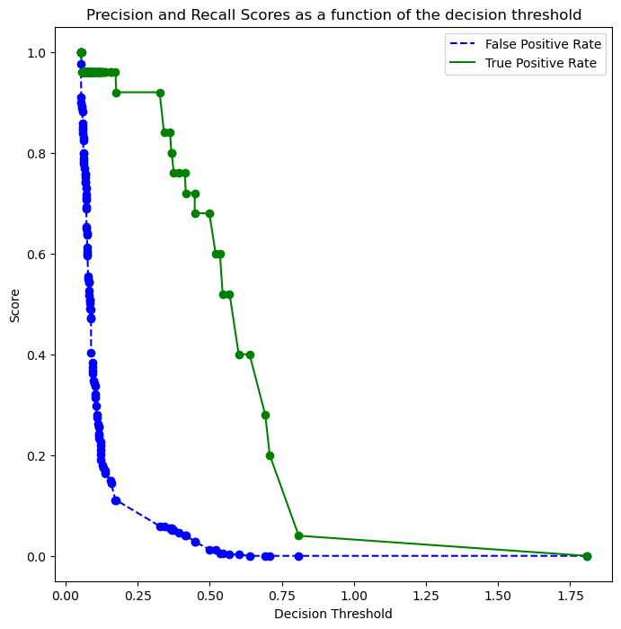

```python
# Model based on the optimal parameters
ada_boost_model = AdaBoostClassifier(random_state=1,
                                     base_estimator = DecisionTreeClassifier(max_depth=1),
                                     learning_rate=0.01,
                                     n_estimators=500).fit(X_train, y_train)


cross_val_ypred = cross_val_predict(AdaBoostClassifier(random_state=1,
                                                       base_estimator = DecisionTreeClassifier(max_depth=1),
                                                       learning_rate=0.02,
                                                       n_estimators=265),
                                    X_train,
                                    y_train,
                                    cv = 5,
                                    method = 'predict_proba')


fpr, tpr, thresholds = roc_curve(y_train, cross_val_ypred[:,1])

def plot_fpr_tpr_vs_threshold(fpr, tpr, thresholds):
    plt.figure(figsize=(8, 8))
    plt.title("Precision and Recall Scores as a function of the decision threshold")
    plt.plot(thresholds, fpr, "b--", label= "False Positive Rate")
    plt.plot(thresholds, tpr, "g-", label= "True Positive Rate")
    plt.plot(thresholds, fpr, "o", color = 'blue')
    plt.plot(thresholds, tpr, "o", color = 'green')
    plt.ylabel("Score")
    plt.xlabel("Decision Threshold")
    plt.legend(loc='best')
    plt.legend()

plot_fpr_tpr_vs_threshold(fpr, tpr, thresholds)
```

```python
# look at feature importances
feature_importance_adaboost = pd.DataFrame({'variables' : X_train.columns,
                                            'feature_importance' : ada_boost_model.feature_importances_})

feature_importance_adaboost.sort_values('feature_importance', ascending = False)
```

|  | variables | feature_importance |
| --- | --- | --- |
| 23 | TOV | 0.244 |
| 7 | 3P | 0.164 |
| 18 | DRB | 0.152 |
| 25 | PTS | 0.098 |
| 19 | TRB | 0.088 |
| 13 | eFG% | 0.078 |
| 12 | 2P% | 0.066 |
| 4 | FG | 0.056 |
| 20 | AST | 0.022 |
| 17 | ORB | 0.016 |
| 5 | FGA | 0.010 |
| 2 | GS | 0.006 |
| 6 | FG% | 0.000 |
| 24 | PF | 0.000 |
| 22 | BLK | 0.000 |
| 21 | STL | 0.000 |
| 3 | MP | 0.000 |
| 16 | FT% | 0.000 |
| 15 | FTA | 0.000 |
| 14 | FT | 0.000 |
| 1 | G | 0.000 |
| 11 | 2PA | 0.000 |
| 10 | 2P | 0.000 |
| 9 | 3P% | 0.000 |
| 8 | 3PA | 0.000 |
| 0 | Age | 0.000 |

```python
# Thresholds with TPR and FPR
all_thresholds = np.concatenate([thresholds.reshape(-1,1), tpr.reshape(-1,1), fpr.reshape(-1,1)], axis = 1)

FPR_below_5 = all_thresholds[all_thresholds[:,2] < 0.10, :]

# we want to maximize TPR while minimizing FPR so go for last one
optimal_thres = FPR_below_5[FPR_below_5.shape[0]-1][0]
```

```
Accuracy:  89.83451536643025
ROC-AUC:  0.9455778894472361
Precision:  0.3392857142857143
Recall:  0.76
```

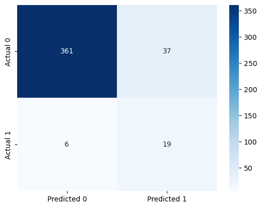

```python
# Performance metrics computation for the optimum decision threshold probability
desired_threshold = optimal_thres

y_pred_prob = ada_boost_model.predict_proba(X_test)[:,1]

# Classifying observations in the positive class (y = 1) if the predicted probability is greater
# than the desired decision threshold probability
y_pred = y_pred_prob > desired_threshold
y_pred = y_pred.astype(int)

#Computing the accuracy
print("Accuracy: ",accuracy_score(y_pred, y_test)*100)

#Computing the ROC-AUC
fpr, tpr, auc_thresholds = roc_curve(y_test, y_pred_prob)
print("ROC-AUC: ",auc(fpr, tpr))# AUC of ROC

#Computing the precision and recall
print("Precision: ", precision_score(y_test, y_pred))
print("Recall: ", recall_score(y_test, y_pred))

#Confusion matrix
cm = pd.DataFrame(confusion_matrix(y_test, y_pred),
                  columns=['Predicted 0', 'Predicted 1'], index = ['Actual 0', 'Actual 1'])
sns.heatmap(cm, annot=True, cmap='Blues', fmt='g');
```

### 3.2 Random Forest

*By Izzy Podolsky*

```python
#Hyperparameter tuning
param_grid = {
    'max_features' : (list(range(1, 19, 2))),
    'n_estimators' : [250, 500, 750]
}

model = RandomForestClassifier(random_state = 1, oob_score = True, verbose = False, n_jobs=-1)

cv = StratifiedKFold(n_splits = 5,shuffle = True, random_state = 1)
rfcv = GridSearchCV(estimator = model,
                           param_grid = param_grid,
                           scoring = ['roc_auc','accuracy'],
                           refit = 'roc_auc',
                           cv = cv,
                          n_jobs = -1,
                          verbose = 1)

result = rfcv.fit(X_train, y_train)

print("Best Accuracy Score: %f" % (result.cv_results_['mean_test_accuracy'][result.best_index_]))
print("Best ROC-AUC Score: %f" % (result.cv_results_['mean_test_roc_auc'][result.best_index_]))
print("Best Hyperparameters: ", result.best_params_)
```

```
Fitting 5 folds for each of 27 candidates, totalling 135 fits
Best Accuracy Score: 0.968557
Best ROC-AUC Score: 0.987349
Best Hyperparameters:  {'max_features': 13, 'n_estimators': 750}
```

```python
#Feature importances
pd.concat([pd.Series(result.best_estimator_.feature_importances_), pd.Series(X_train.columns)], axis=1).sort_values(by = 0,ascending = False)
```

|  | 0 | 1 |
| --- | --- | --- |
| 25 | 0.228015 | PTS |
| 4 | 0.212102 | FG |
| 5 | 0.071567 | FGA |
| 13 | 0.067834 | eFG% |
| 23 | 0.055689 | TOV |
| 14 | 0.055427 | FT |
| 18 | 0.034718 | DRB |
| 15 | 0.029607 | FTA |
| 7 | 0.029301 | 3P |
| 3 | 0.028974 | MP |
| 12 | 0.023936 | 2P% |
| 20 | 0.020510 | AST |
| 19 | 0.019386 | TRB |
| 8 | 0.018371 | 3PA |
| 10 | 0.017462 | 2P |
| 2 | 0.014446 | GS |
| 11 | 0.012283 | 2PA |
| 6 | 0.010501 | FG% |
| 0 | 0.009289 | Age |
| 24 | 0.007796 | PF |
| 17 | 0.006791 | ORB |
| 16 | 0.006418 | FT% |
| 21 | 0.006205 | STL |
| 1 | 0.006063 | G |
| 9 | 0.004950 | 3P% |
| 22 | 0.002358 | BLK |

```
0.11
```

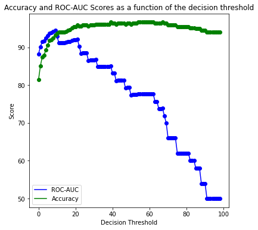

```python
#threshold tuning
cross_val_ypred = cross_val_predict(RandomForestClassifier(random_state = 1, oob_score = True, verbose = False, n_jobs=-1, max_depth = 3, n_estimators = 250), X_train, y_train, cv = 5, method = 'predict_proba')

def plot_accuracy_recall_vs_threshold(y_proba, y_true):
    ra_iter = []
    accuracy_iter = []
    threshold_val = 100
    threshold_hyperparam_vals = np.arange(0.01, 1, 0.01)
    for threshold_prob in threshold_hyperparam_vals:
        predicted_class = y_proba[:,1] > threshold_prob
        predicted_class = predicted_class.astype(int)
        accuracy = accuracy_score(y_true, predicted_class)*100
        rocauc = roc_auc_score(y_true, predicted_class)*100
        accuracy_iter.append(accuracy)
        ra_iter.append(rocauc)
        if (accuracy > rocauc) & (threshold_prob < threshold_val):
            threshold_val = threshold_prob
            print(threshold_val)

    plt.figure(figsize=(6, 6))
    plt.title("Accuracy and ROC-AUC Scores as a function of the decision threshold")
    plt.plot(ra_iter, "b-", label= "ROC-AUC")
    plt.plot(accuracy_iter, "g-", label="Accuracy")
    plt.plot(ra_iter, "o", color = 'blue')
    plt.plot(accuracy_iter, "o", color = 'green')
    plt.ylabel("Score")
    plt.xlabel("Decision Threshold")
    plt.legend(loc='best')
    plt.legend()

plot_accuracy_recall_vs_threshold(cross_val_ypred, y_train)
```

```python
model = RandomForestClassifier(
    random_state = 1,
    oob_score = True,
    verbose = False,
    n_jobs=-1,
    max_depth = 3,
    n_estimators = 250).fit(X_train, y_train)
```

```
Accuracy: 0.900709219858156
Recall: 0.72
Precision: 0.33962264150943394
ROC_AUC: 0.8160301507537688
```

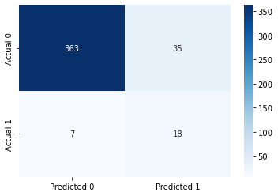

```python
y_pred = (model.predict_proba(X_test)[:,1] > .11).astype(int)

#computing scores
accuracy = accuracy_score(y_test, y_pred)
recall = recall_score(y_test, y_pred)
precision = precision_score(y_test, y_pred)
roc_auc = roc_auc_score(y_test, y_pred)

print("Accuracy:", accuracy)
print("Recall:", recall)
print("Precision:", precision)
print("ROC_AUC:", roc_auc)

#Confusion matrix
cm = pd.DataFrame(confusion_matrix(y_test, y_pred),
                  columns=['Predicted 0', 'Predicted 1'], index = ['Actual 0', 'Actual 1'])
sns.heatmap(cm, annot=True, cmap='Blues', fmt='g');
```

### 3.3 Bagged trees

*By Shray Vaidya*

```python
#Finding optimal hyperparameters
n_samples = X_train.shape[0]
n_features = X_train.shape[1]

params = {'base_estimator': [DecisionTreeClassifier(random_state = 1)],
          'n_estimators': [250,300,350,400,450,500,550],
          'max_samples': [0.5, 0.6, 0.7, 0.8, 0.9, 1.0],
          'max_features': [0.5, 0.6, 0.7, 0.8, 0.9, 1.0],
          'bootstrap': [True, False],
          'bootstrap_features': [True, False]}


cv = KFold(n_splits=5,shuffle=True,random_state=1)
bagging_classifier_grid = GridSearchCV(BaggingClassifier(random_state=1, n_jobs=-1),
                                      param_grid =params, cv=cv, n_jobs=-1, verbose=1,
                                      scoring = ['roc_auc', 'accuracy'], refit='roc_auc')
res = bagging_classifier_grid.fit(X_train, y_train)

print("Best Recall Score: %f" % (res.cv_results_['mean_test_accuracy'][res.best_index_]))
print("Best ROC-AUC Score: %f" % (res.cv_results_['mean_test_roc_auc'][res.best_index_]))
print("Best Hyperparameters: ", res.best_params_)
```

```
Fitting 5 folds for each of 1008 candidates, totalling 5040 fits
Best Recall Score: 0.978313
Best ROC-AUC Score: 0.994053
Best Hyperparameters:  {'base_estimator': DecisionTreeClassifier(random_state=1), 'bootstrap': False, 'bootstrap_features': False, 'max_features': 0.9, 'max_samples': 0.8, 'n_estimators': 250}
```

```python
#Best model
model = bagging_classifier_grid.best_estimator_
#Feature importances
# Data structure to store sum of feature importance and number of times it showed up
total = [0] * 26
# Loop through every tree in bagging regressor
for i, temp_model in enumerate(model.estimators_): # model is bagging regressor
    feature = model.estimators_features_[i] # Get the predictors the specific tree uses
    for j, predictor in enumerate(feature): # loop the predictors
        total[predictor] += temp_model.feature_importances_[j] # Add the specific feature importance to the array
imps = np.array(total)/len(model.estimators_) #convert to numpy array for easy elementwise division

pd.Series(imps, index = X_train.columns).sort_values(ascending = False)
```

```
PTS     0.532374
eFG%    0.144383
FG      0.081132
TOV     0.057140
3P      0.020639
AST     0.019018
DRB     0.018758
TRB     0.017966
FGA     0.014549
3PA     0.013680
FT%     0.013031
FT      0.008626
MP      0.008054
2P%     0.007537
G       0.005626
2P      0.005586
2PA     0.004580
PF      0.004360
Age     0.004100
GS      0.003779
3P%     0.003158
FG%     0.003131
ORB     0.002903
FTA     0.002264
STL     0.002167
BLK     0.001461
dtype: float64
```

```
0.012
```

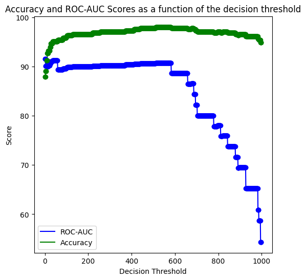

```python
cross_val_ypred = cross_val_predict(model, X_train, y_train, cv = 5, method = 'predict_proba')

def plot_accuracy_recall_vs_threshold(y_proba, y_true):
    ra_iter = []
    accuracy_iter = []
    threshold_val = 100
    threshold_hyperparam_vals = np.arange(0.001, 1, 0.001)
    for threshold_prob in threshold_hyperparam_vals:
        predicted_class = y_proba[:,1] > threshold_prob
        predicted_class = predicted_class.astype(int)
        accuracy = accuracy_score(y_true, predicted_class)*100
        rocauc = roc_auc_score(y_true, predicted_class)*100
        accuracy_iter.append(accuracy)
        ra_iter.append(rocauc)
        if (accuracy > rocauc) & (threshold_prob < threshold_val):
            threshold_val = threshold_prob
            print(threshold_val)

    plt.figure(figsize=(6, 6))
    plt.title("Accuracy and ROC-AUC Scores as a function of the decision threshold")
    plt.plot(ra_iter, "b-", label= "ROC-AUC")
    plt.plot(accuracy_iter, "g-", label="Accuracy")
    plt.plot(ra_iter, "o", color = 'blue')
    plt.plot(accuracy_iter, "o", color = 'green')
    plt.ylabel("Score")
    plt.xlabel("Decision Threshold")
    plt.legend(loc='best')
    plt.legend()

plot_accuracy_recall_vs_threshold(cross_val_ypred, y_train)
```

```
Accuracy:  87.70685579196218
ROC-AUC:  0.8367391304347825
Precision:  0.26229508196721313
Recall:  0.6956521739130435
```

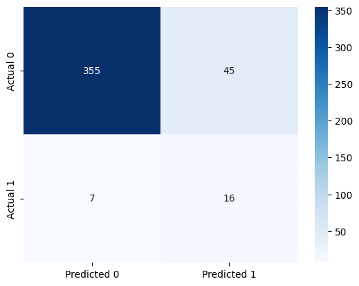

```python
# Performance metrics computation for the optimum decision threshold probability
desired_threshold = 0.012

y_pred_prob = model.predict_proba(X_test)[:,1]

# Classifying observations in the positive class (y = 1) if the predicted probability is greater
# than the desired decision threshold probability
y_pred = y_pred_prob > desired_threshold
y_pred = y_pred.astype(int)

#Computing the accuracy
print("Accuracy: ",accuracy_score(y_pred, y_test)*100)

#Computing the ROC-AUC
fpr, tpr, auc_thresholds = roc_curve(y_test, y_pred_prob)
print("ROC-AUC: ",auc(fpr, tpr))# AUC of ROC

#Computing the precision and recall
print("Precision: ", precision_score(y_test, y_pred))
print("Recall: ", recall_score(y_test, y_pred))

#Confusion matrix
cm = pd.DataFrame(confusion_matrix(y_test, y_pred),
                  columns=['Predicted 0', 'Predicted 1'], index = ['Actual 0', 'Actual 1'])
sns.heatmap(cm, annot=True, cmap='Blues', fmt='g');
```

### 3.4 XGBoost

*By Davis Johnson*

```python
## hyperparameter tuning

scale_pos_weight = np.sum(y_train == 0) / np.sum(y_train == 1)

param_grid = {
    'n_estimators': [21,22,23,24,25,26,27],
    'max_depth': [4,5,6],
    'learning_rate': [0.06,0.07,0.08,0.09,0.1,0.2,0.3,0.4,0.5,0.6,0.7,0.8,0.9,1.0],
    'gamma': [0,1,2,3],
    'reg_lambda': [30,40,60,80,90,100,150,200],
    'subsample': [0.1,0.2,0.3,0.4,0.5,0.6,0.7,0.8,0.9,1.0],
    'scale_pos_weight': [scale_pos_weight],
    'colsample_bytree': [0.1,0.2,0.3,0.4,0.5,0.6,0.7,0.8,0.9,1.0]
}

xgb_model = xgb.XGBClassifier(objective = 'binary:logistic',random_state=1,use_label_encoder=False)




cv = StratifiedKFold(n_splits=5,shuffle=True,random_state=1)
rs_cv = RandomizedSearchCV(estimator=xgb_model,
                           random_state=1,
                           param_distributions=param_grid,
                           scoring=['recall','accuracy','roc_auc'],
                           refit='roc_auc',
                           cv=cv,
                          n_jobs=-1,
                          verbose=1,
                          n_iter=2000)

grid_result = rs_cv.fit(X_train, y_train)
print("Best Accuracy Score: %f" % (grid_result.cv_results_['mean_test_accuracy'][grid_result.best_index_]))
print("Best Recall Score: %f" % (grid_result.cv_results_['mean_test_recall'][grid_result.best_index_]))
print("Best ROC-AUC Score: %f" % (grid_result.cv_results_['mean_test_roc_auc'][grid_result.best_index_]))
print("Best Hyperparameters: ", grid_result.best_params_)
```

```
Fitting 5 folds for each of 2000 candidates, totalling 10000 fits
```

```
Best Accuracy Score: 0.937232
Best Recall Score: 0.920000
Best ROC-AUC Score: 0.986580
Best Hyperparameters:  {'subsample': 1.0, 'scale_pos_weight': 15.56, 'reg_lambda': 90, 'n_estimators': 26, 'max_depth': 6, 'learning_rate': 0.09, 'gamma': 0, 'colsample_bytree': 0.3}
```

```python
# analyzing cv results to get potentially better combinations
cv_results_df = pd.DataFrame(grid_result.cv_results_)
subset_df = cv_results_df[(cv_results_df['mean_test_accuracy'] > 0.946) & (cv_results_df['mean_test_recall'] >= 0.91)]
subset_df[['param_subsample','param_scale_pos_weight','param_reg_lambda','param_n_estimators','param_max_depth',
          'param_learning_rate', 'param_gamma', 'param_colsample_bytree','mean_test_accuracy','mean_test_recall','mean_test_roc_auc']]
```

|  | param_subsample | param_scale_pos_weight | param_reg_lambda | param_n_estimators | param_max_depth | param_learning_rate | param_gamma | param_colsample_bytree | mean_test_accuracy | mean_test_recall | mean_test_roc_auc |
| --- | --- | --- | --- | --- | --- | --- | --- | --- | --- | --- | --- |
| 326 | 1.0 | 15.56 | 40 | 26 | 5 | 0.1 | 0 | 0.3 | 0.94690 | 0.92 | 0.984003 |
| 1544 | 0.9 | 15.56 | 150 | 21 | 4 | 0.5 | 0 | 0.3 | 0.94690 | 0.92 | 0.980616 |
| 1848 | 1.0 | 15.56 | 200 | 26 | 6 | 0.4 | 1 | 0.4 | 0.94687 | 0.92 | 0.977249 |

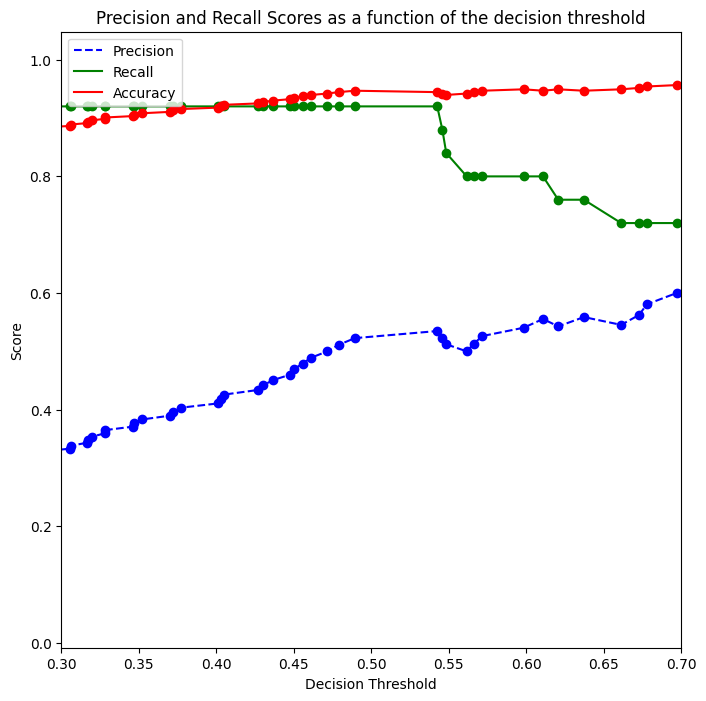

```python
# finding optimal threshold

scale_pos_weight = np.sum(y_train == 0) / np.sum(y_train == 1)

model = xgb.XGBClassifier(objective='binary:logistic', use_label_encoder=False, max_depth=5,
                          n_estimators=26, learning_rate=0.1, scale_pos_weight=scale_pos_weight,
                          subsample=1.0, gamma=0, reg_lambda=40, colsample_bytree=0.3, random_state=1).fit(X_train, y_train)



cv = StratifiedKFold(n_splits=5,shuffle=True,random_state=1)
cross_val_ypred = cross_val_predict(model, X_train, y_train, cv = cv, method = 'predict_proba')

p, r, thresholds = precision_recall_curve(y_train, cross_val_ypred[:,1])
acc = np.ndarray(shape = (len(thresholds),))
i = 0
for th in thresholds:
    y_pred = cross_val_ypred[:,1] > th
    y_pred = y_pred.astype(int)
    acc[i] = accuracy_score(y_pred, y_train)
    i = i + 1
def plot_precision_recall_vs_threshold(precisions, recalls, thresholds):
    plt.figure(figsize=(8, 8))
    plt.title("Precision and Recall Scores as a function of the decision threshold")
    plt.plot(thresholds, precisions[:-1], "b--", label="Precision")
    plt.plot(thresholds, recalls[:-1], "g-", label="Recall")
    plt.plot(thresholds, acc, "r-", label="Accuracy")
    plt.plot(thresholds, precisions[:-1], "o", color = 'blue')
    plt.plot(thresholds, recalls[:-1], "o", color = 'green')
    plt.plot(thresholds, acc, "o", color = 'red')
    plt.ylabel("Score")
    plt.xlabel("Decision Threshold")
    plt.xlim(0.3,0.7)
    plt.legend(loc='best')
    plt.legend()
plot_precision_recall_vs_threshold(p, r, thresholds)
```

```
Accuracy:  87.94326241134752
ROC-AUC:  0.9432663316582914
Precision:  0.3194444444444444
Recall:  0.92
```

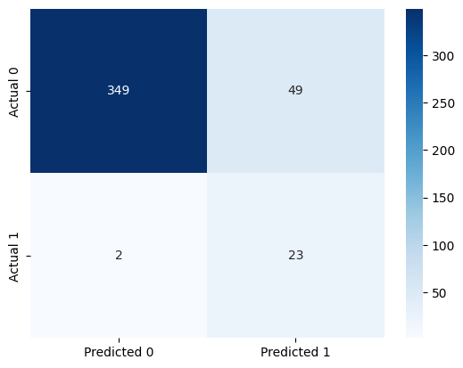

```python
# desired threshold found using trial and error based on above graph, wanted to improve recall a little on test data
desired_threshold = 0.28927049

y_pred_prob = model.predict_proba(X_test)[:,1]

y_pred = y_pred_prob > desired_threshold
y_pred = y_pred.astype(int)


print("Accuracy: ",accuracy_score(y_pred, y_test)*100)


fpr, tpr, auc_thresholds = roc_curve(y_test, y_pred_prob)
print("ROC-AUC: ",auc(fpr, tpr))# AUC of ROC


print("Precision: ", precision_score(y_test, y_pred))
print("Recall: ", recall_score(y_test, y_pred))


cm = pd.DataFrame(confusion_matrix(y_test, y_pred),
                  columns=['Predicted 0', 'Predicted 1'], index = ['Actual 0', 'Actual 1'])
sns.heatmap(cm, annot=True, cmap='Blues', fmt='g');
```

## 4 Model Ensemble (Izzy)

### 4.1 Voting ensemble

```python
## creating base models
logreg = LogisticRegression(solver = 'newton-cg').fit(X_train,y_train)

model_ada = AdaBoostClassifier(random_state=1,
                                     base_estimator = DecisionTreeClassifier(max_depth=1),
                                     learning_rate=0.02,
                                     n_estimators=265).fit(X_train, y_train)

model_bag = BaggingClassifier(base_estimator = DecisionTreeClassifier(random_state=1),
                              bootstrap = False,
                              bootstrap_features = False,
                              max_features = 0.9,
                              max_samples = 0.8,
                              n_estimators = 250).fit(X_train, y_train)

model_rf = RandomForestClassifier(
    random_state = 1,
    oob_score = True,
    verbose = False,
    n_jobs=-1,
    max_depth = 3,
    n_estimators = 250).fit(X_train, y_train)

model_gb = GradientBoostingClassifier(random_state=1,
                                   max_depth=15,
                                   learning_rate=0.001,
                                   subsample=0.6,
                                   n_estimators=100).fit(X_train,y_train)

model_xgb = xgb.XGBClassifier(objective='binary:logistic', use_label_encoder=False, max_depth=5,
                          n_estimators=26, learning_rate=0.1, scale_pos_weight=15.56,
                          subsample=1.0, gamma=0, reg_lambda=40, colsample_bytree=0.3, random_state=1).fit(X_train,y_train)
```

```python
## ensemble 1: hard voting ensemble
hensemble_model = VotingClassifier(estimators=[('log', logreg), ('bag',model_bag), ('ada',model_ada),('rf',model_rf),('gb',model_gb),('xgb',model_xgb)])
hensemble_model.fit(X_train,y_train)
hensemble_model.score(X_test, y_test)
```

```
0.9408983451536643
```

```python
#finding model recall
y_pred_hensemble = hensemble_model.predict(X_test)
recall_hensemble = recall_score(y_test, y_pred_hensemble)
recall_hensemble
```

```
0.56
```

```python
## ensemble 2: soft voting ensemble: without threshold tuning
sensemble_model = VotingClassifier(estimators=[('log', logreg), ('bag',model_bag), ('ada',model_ada),('rf',model_rf),('gb',model_gb),('xgb',model_xgb)], voting = 'soft')
sensemble_model.fit(X_train,y_train)
y_pred_probs_test = sensemble_model.predict(X_test)
accuracy_test = accuracy_score(y_test, y_pred_test)
recall_test = recall_score(y_test, y_pred_test)
print("Accuracy on test data: ", accuracy_test)
print("Recall on test data: ", recall_test)
```

```
Accuracy on test data:  0.9314420803782506
Recall on test data:  0.52
```

```
0.2
```

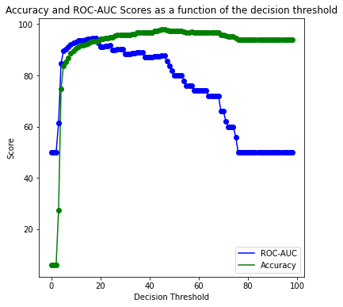

```python
# tuning threshold using average predictions:
y_pred_probs1 = cross_val_predict(logreg, X_train, y_train, cv=5, method='predict_proba')
y_pred_probs2 = cross_val_predict(model_bag, X_train, y_train, cv=5, method='predict_proba')
y_pred_probs3 = cross_val_predict(model_xgb, X_train, y_train, cv=5, method='predict_proba')
y_pred_probs4 = cross_val_predict(model_rf, X_train, y_train, cv=5, method='predict_proba')
y_pred_probs5 = cross_val_predict(model_ada, X_train, y_train, cv=5, method='predict_proba')
y_pred_probs6 = cross_val_predict(model_gb, X_train, y_train, cv=5, method='predict_proba')

avg_pred_probs = (y_pred_probs1 + y_pred_probs2 + y_pred_probs3 + y_pred_probs4 + y_pred_probs5 + y_pred_probs6) / 6

def plot_accuracy_recall_vs_threshold(y_proba, y_true):
    ra_iter = []
    accuracy_iter = []
    threshold_val = 100
    threshold_hyperparam_vals = np.arange(0.01, 1, 0.01)
    for threshold_prob in threshold_hyperparam_vals:
        predicted_class = avg_pred_probs[:, 1] > threshold_prob
        predicted_class = predicted_class.astype(int)
        accuracy = accuracy_score(y_true, predicted_class)*100
        rocauc = roc_auc_score(y_true, predicted_class)*100
        accuracy_iter.append(accuracy)
        ra_iter.append(rocauc)
        if (accuracy > rocauc) & (threshold_prob < threshold_val):
            threshold_val = threshold_prob
            print(threshold_val)

    plt.figure(figsize=(6, 6))
    plt.title("Accuracy and ROC-AUC Scores as a function of the decision threshold")
    plt.plot(ra_iter, "b-", label= "ROC-AUC")
    plt.plot(accuracy_iter, "g-", label="Accuracy")
    plt.plot(ra_iter, "o", color = 'blue')
    plt.plot(accuracy_iter, "o", color = 'green')
    plt.ylabel("Score")
    plt.xlabel("Decision Threshold")
    plt.legend(loc='best')
    plt.legend()


plot_accuracy_recall_vs_threshold(avg_pred_probs, y_train)
```

```python
## ensemble 2: soft voting ensemble: with threshold tuning
y_pred_probs_test = sensemble_model.predict_proba(X_test)
y_pred_test = (y_pred_probs_test[:, 1] >= 0.2).astype(int)
accuracy_test = accuracy_score(y_test, y_pred_test)
recall_test = recall_score(y_test, y_pred_test)
print("Accuracy on test data: ", accuracy_test)
print("Recall on test data: ", recall_test)
```

```
Accuracy on test data:  0.8983451536643026
Recall on test data:  0.68
```

### 4.2 Stacking ensemble(s)

```python
## final estimator is log_reg -- without C tuning
lensemble_model = StackingClassifier(estimators=[('log', logreg), ('bag',model_bag), ('ada',model_ada),('rf',model_rf),('gb',model_gb),('xgb',model_xgb)],
                                   final_estimator=LogisticRegression(random_state = 1,max_iter = 10000),n_jobs=-1,
                                   cv = StratifiedKFold(n_splits=5,shuffle=True,random_state = 1))
lensemble_model.fit(X_train,y_train)
lensemble_model.score(X_test, y_test)
```

```
0.933806146572104
```

```python
# tuning c
logpreds = logreg.predict_proba(X_train)[:, 1]
preds_gb_train = model_gb.predict_proba(X_train)[:, 1]
preds_ada_train = model_ada.predict_proba(X_train)[:, 1]
preds_bag_train = model_bag.predict_proba(X_train)[:, 1]
preds_rf_train = model_rf.predict_proba(X_train)[:, 1]
preds_xgb_train = model_xgb.predict_proba(X_train)[:, 1]

meta_features_train = np.column_stack((logpreds, preds_rf_train, preds_xgb_train, preds_gb_train, preds_bag_train, preds_ada_train))


best_c = None
best_accuracy = 0.0
best_ra = 0.0

for c_val in 10**np.linspace(-2.5, 2):
    metamodel = LogisticRegression(random_state=1, max_iter=1000, C=c_val)
    scoring = ['accuracy', 'roc_auc']
    scores = cross_validate(metamodel, meta_features_train, y_train, cv=5, scoring=scoring)

    mean_accuracy = np.mean(scores['test_accuracy'])
    mean_ra = np.mean(scores['test_roc_auc'])

    if mean_ra > best_ra and mean_accuracy > best_accuracy:
        best_accuracy = mean_accuracy
        best_ra = mean_ra
        best_c = c_val

print("Best C value:", best_c)
print("Best Accuracy:", best_accuracy)
print("Best ROC_AUC:", best_ra)
```

```
Best C value: 0.0031622776601683794
Best Accuracy: 0.9396121069644432
Best ROC_AUC: 1.0
```

```python
# threshold tuning
metamodel = LogisticRegression(max_iter=1000, C=best_c)
metamodel.fit(meta_features_train, y_train)

preds_meta = metamodel.predict_proba(meta_features_train)[:, 1]

best_threshold = None
best_accuracy = 0.0
best_ra = 0.0

for threshold in np.linspace(0, 1, 101):

    y_pred = (preds_meta >= threshold).astype(int)

    accuracy = accuracy_score(y_train, y_pred)
    ra = roc_auc_score(y_train, y_pred)

    if ra > best_ra and accuracy > best_accuracy: #maximizing both
        best_accuracy = accuracy
        best_ra = ra
        best_threshold = threshold

print("Best Threshold:", best_threshold)
print("Best Accuracy:", best_accuracy)
print("Best RA:", best_ra)
```

```
Best Threshold: 0.06
Best Accuracy: 0.9009661835748792
Best RA: 0.9473007712082262
```

```python
# final stacking model with tuned C and threshold
logpred = logreg.predict_proba(X_test)[:, 1]
preds_gb_t = model_gb.predict_proba(X_test)[:, 1]
preds_ada_t = model_ada.predict_proba(X_test)[:, 1]
preds_bag_t = model_bag.predict_proba(X_test)[:, 1]
preds_rf_t = model_rf.predict_proba(X_test)[:, 1]
preds_xgb_t = model_xgb.predict_proba(X_test)[:, 1]

meta_features_t = np.column_stack((logpred, preds_rf_t, preds_xgb_t, preds_gb_t, preds_bag_t, preds_ada_t))

threshold = 0.06

metamodel = LogisticRegression(max_iter=10000, C= best_c)
metamodel.fit(meta_features_train, y_train)

y_pred_probs_test = metamodel.predict_proba(meta_features_t)

y_pred_test = (y_pred_probs_test[:, 1] >= threshold).astype(int)

accuracy_test = accuracy_score(y_test, y_pred_test)
recall_test = recall_score(y_test, y_pred_test)

print("Accuracy on test data: ", accuracy_test)
print("Recall on test data: ", recall_test)
```

```
Accuracy on test data:  0.8581560283687943
Recall on test data:  0.92
```

## 5 Conclusions and Recommendations to stakeholder(s)

See Project Report.